# SGLT2 Inhibitors vs. Placebo for Heart Failure Hospitalization in Type 2 Diabetes with Established ASCVD

A reproducible meta-analysis

Author

Said Adjao

Published

June 22, 2026

## 1 Summary

This report synthesizes SGLT2 inhibitors versus placebo for heart failure hospitalization in adults with type 2 diabetes and established atherosclerotic cardiovascular disease (ASCVD). Pooling 4 trials, SGLT2 inhibitors were associated with a significantly lower risk of HF hospitalization (pooled hazard ratio **0.7**, 95% CI 0.62 to 0.78) — an approximately 30% relative reduction — with no detectable between-study heterogeneity (I² = 0%).

## 2 Background

Heart failure is a frequent and costly complication of type 2 diabetes, and hospitalization for heart failure is a key driver of both morbidity and healthcare expenditure. SGLT2 inhibitors have demonstrated cardiovascular benefit, but coverage and guideline positioning depend on the strength of the evidence in specific populations. This analysis synthesizes the randomized evidence for HF hospitalization in patients with established ASCVD.

## 3 Methods

### 3.1 Eligibility criteria

Randomized controlled trials were eligible if they enrolled adults with type 2 diabetes and established ASCVD (prior MI, angina, coronary or peripheral revascularization, ischaemic stroke, or symptomatic PAD), compared an SGLT2 inhibitor against placebo, and reported hospitalization for heart failure. Trials enrolling primarily on chronic kidney disease or on heart failure were excluded, to keep the population defined by atherosclerotic disease.

### 3.2 Information sources and study selection

A PubMed search (RCT filter, 2013–present) returned 250 records. After removal of duplicates, records were screened in two stages — title/abstract, then full text — using Rayyan. Secondary analyses and substudies were excluded so that each trial was represented by a single primary results paper. Four cardiovascular outcome trials met criteria: EMPA-REG OUTCOME, CANVAS Program, DECLARE-TIMI 58, and VERTIS-CV.

### 3.3 Data extraction

Hospitalization for heart failure was extracted as a hazard ratio with 95% confidence interval from each trial. Hazard ratios were chosen because these are time-to-event trials with differing follow-up; raw per-arm event counts were not uniformly reported (CANVAS, for example, reported event rates rather than counts), making the hazard ratio the consistent and appropriate effect measure across trials.

### 3.4 Statistical analysis

Effects were pooled using an inverse-variance random-effects model on the log scale, implemented with the `meta` package in R. Random effects were chosen a priori because the trials differed in SGLT2 inhibitor, follow-up duration, and population composition, making a single common true effect implausible. Heterogeneity was quantified with I².

## 4 Results

Hazard ratio for HF hospitalization (SGLT2i vs placebo). HR < 1 favors SGLT2i.

| Study | HR | 95% CI |
| --- | --- | --- |
| EMPA-REG OUTCOME | 0.65 | (0.5, 0.85) |
| CANVAS Program | 0.67 | (0.52, 0.87) |
| DECLARE-TIMI 58 | 0.73 | (0.61, 0.88) |
| VERTIS-CV | 0.70 | (0.54, 0.9) |

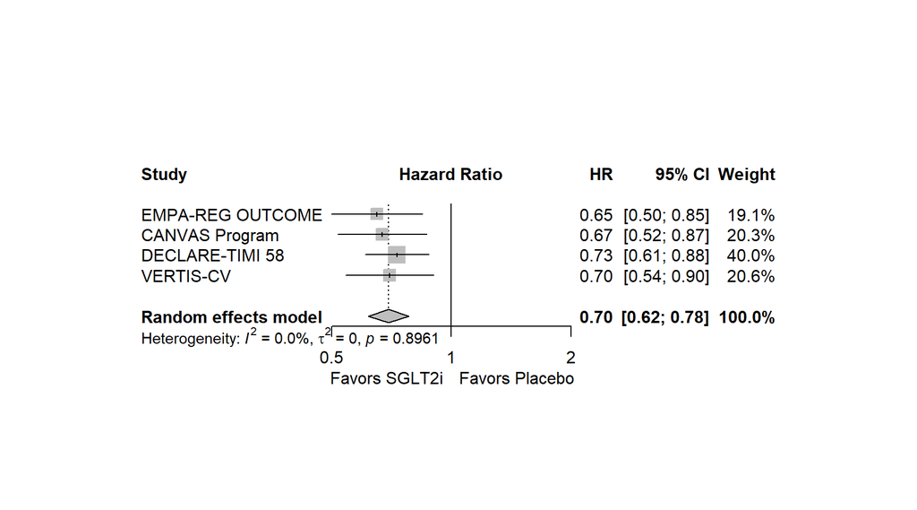

Pooling all 4 trials, SGLT2 inhibitors significantly reduced HF hospitalization (HR **0.7**; 95% CI 0.62 to 0.78). Between-study heterogeneity was absent (I² = 0%). Unlike synthesis of a small or imprecise evidence base, this near-zero heterogeneity reflects genuine consistency across four large trials with tight confidence intervals, supporting a robust and reliable effect.

## 5 Limitations

The evidence base comprises four trials; although each is large and the pooled estimate is precise, four studies remain a modest number. Two trials (DECLARE-TIMI 58, CANVAS Program) enrolled mixed populations including primary-prevention participants, so the analysis is not restricted purely to secondary prevention. Hospitalization for heart failure was a secondary outcome in most trials. Finally, effect estimates were extracted as reported hazard ratios rather than re-derived from individual patient data.

## 6 References

1. Zinman B, Wanner C, Lachin JM, et al. Empagliflozin, cardiovascular outcomes, and mortality in type 2 diabetes (EMPA-REG OUTCOME). *N Engl J Med.* 2015;373(22):2117–2128.
2. Neal B, Perkovic V, Mahaffey KW, et al. Canagliflozin and cardiovascular and renal events in type 2 diabetes (CANVAS Program). *N Engl J Med.* 2017;377(7):644–657.
3. Wiviott SD, Raz I, Bonaca MP, et al. Dapagliflozin and cardiovascular outcomes in type 2 diabetes (DECLARE-TIMI 58). *N Engl J Med.* 2019;380(4):347–357.
4. Cannon CP, Pratley R, Dagogo-Jack S, et al. Cardiovascular outcomes with ertugliflozin in type 2 diabetes (VERTIS-CV). *N Engl J Med.* 2020;383(15):1425–1435.